# easy geom recipes: compute_group

Gina Reynolds, Morgan Brown

1/3/2022

Using ggplot2 has been described as writing ‘graphical poems’. But we may feel at a loss for ‘words’ when functions we’d like to have don’t exist. The ggplot2 extension system allows us to build new ‘vocabulary’ for fluent expression.

An exciting extension mechanism is that of inheriting from existing, more primitive geoms after performing some calculation.

To get your feet wet in this world and give you a taste of patterns for geom extension, we provide three basic examples of the geoms_ that inherit from *existing* geoms (point, text, segment, etc) along with a practice exercise. With such geoms, calculation is done under the hood by the ggplot2 system. We’ll see how to define a ggproto object; in this tutorial we’ll keep things simple by only defining computation at the compute_group stage.

With new geom, you can write *new* graphical poems with exciting new graphical ‘words’!

This tutorial is intended for individuals who already have a working knowledge of the grammar of ggplot2, but may like to build a richer vocabulary for themselves.

# Preview

Our recipes take the form:

- *Step 0. Get the job done with ‘base’ ggplot2.* It’s a good idea to clarify what needs to happen without getting into the extension architecture
- *Step 1. Write a computation function.* Wrap the necessary computation into a function that your target geom_*() function will perform. We focus on ‘compute_group’ computation only in this tutorial.
- *Step 2. Define a ggproto object.* ggproto objects allow your extension to work together with base ggplot2 functions! You’ll use the computation function from step 1 to help define it.
- *Step 3. Write your geom function!* You’re ready to write your function. You will incorporate the ggproto from step 2 and also define which more primitive geom (point, text, segment etc) you want other behaviors to inherit from.
- *Step 4. Test/Enjoy!* Take your new geom for a spin! Check out group-wise computation behavior!

Below, you’ll see a completely worked example (example recipes) and then a invitation to build a related target geom_*().

# Step 00

prestep to this tutorial is loading packages and prepping data

```r
library(tidyverse)
library(palmerpenguins)
# handling missingness is not a discussion of this tutorial, so we'll only use complete cases
penguins <- remove_missing(penguins)
```

# Example recipe #1: `geom_point_xy_medians()`

–

- This will be a point at the median of x and y

## Step 0: use base ggplot2 to get the job done

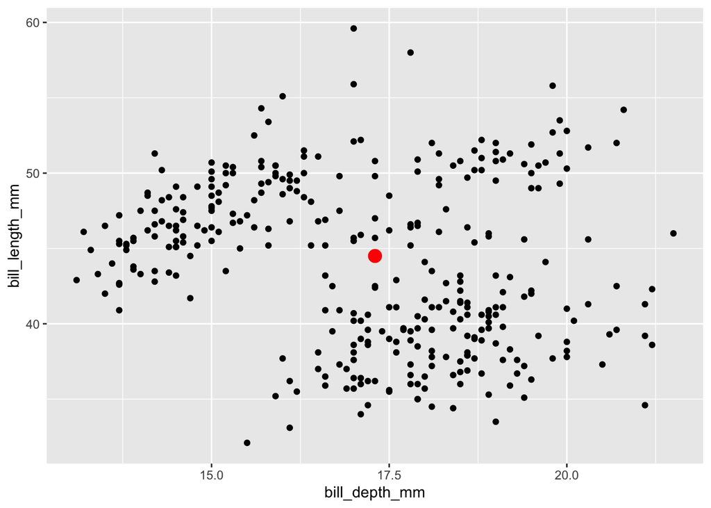

```r
penguins_medians <- penguins %>%
  summarize(bill_length_mm_median = median(bill_length_mm),
            bill_depth_mm_median = median(bill_depth_mm))

penguins %>%
  ggplot() +
  aes(x = bill_depth_mm) +
  aes(y = bill_length_mm) +
  geom_point() +
  geom_point(data = penguins_medians,
    color = "red", size = 4,
             aes(x = bill_depth_mm_median,
                 y = bill_length_mm_median))
```

## Step 1: computation

```r
# Step 1.a
compute_group_xy_medians <- function(data, scales){ #  scales is used internally in ggplot2
  data %>%
    summarize(x = median(x),
            y = median(y))
}

# Step 1.b
penguins %>%
  # prep data to look like it will inside of ggplot2
  rename(x = bill_depth_mm,       # ggplot2 will work with *aes* column names
         y = bill_length_mm) %>%  # therefore rename is required to used the compute function
  select(x, y) %>%  # ggplot will use only variables, i.e. variables mapped to aesthetics for your target layer
  compute_group_xy_medians()
```

```
## # A tibble: 1 × 2
##       x     y
##   <dbl> <dbl>
## 1  17.3  44.5
```

## Step 2: define ggproto

In the background, when you build ggplot2 plots, you are defining a plot specification. The `+` in ggplot2 and the proto system allows you to update your specification (changing the aesthetic mapping, adding layers, changing scales to be used, etc).

The ggproto function allows you to define a new class that’s usable within the ggplot2 ecosystem; that is, you can do updating using extension packages.

https://ggplot2.tidyverse.org/reference/ggproto.html

Things to notice:

- **What’s the naming convention for the proto object?** *The name of your class is the same as the object you create; also, it is convention to use camel case for ggproto objects.*
- **What is the inherited class?** *In fact, your ggproto object is a subclass and you aren’t fully defining it. You inherit the class properties of ggplot2::Stat.*
- **Which aesthetics are required as inputs?** *Generally, you will have required aesthetics; in this case, you specify that one must define the variable that goes on the x and y axis.*
- **Where does the function from above go?** *We input the computational function defined above at the compute_group argument.*

```r
StatXYMedians <- ggplot2::ggproto(`_class` = "StatXYMedians",
                                  `_inherit` = ggplot2::Stat,
                                  required_aes = c("x", "y"),
                                  compute_group = compute_group_xy_medians)
```

## Step 3: define geom_* function

Things to notice

- Where does our work up to this point enter in?
- What more primitive geom will we inherit behavior from?

```r
geom_point_xy_medians <- function(mapping = NULL, data = NULL,
                           position = "identity", na.rm = FALSE,
                           show.legend = NA,
                           inherit.aes = TRUE, ...) {
  ggplot2::layer(
    stat = StatXYMedians,        # proto object from step 2
    geom = ggplot2::GeomPoint,   # inherit other behavior
    data = data,
    mapping = mapping,
    position = position,
    show.legend = show.legend,
    inherit.aes = inherit.aes,
    params = list(na.rm = na.rm, ...)
  )
}
```

## Step 4: Enjoy! Use your function

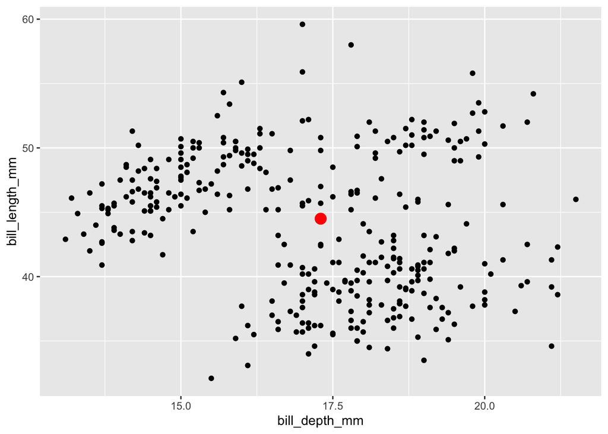

```r
penguins %>%
  ggplot() +
  aes(x = bill_depth_mm, y = bill_length_mm) +
  geom_point() +
  geom_point_xy_medians(color = "red", size = 4)
```

### And check out conditionality!

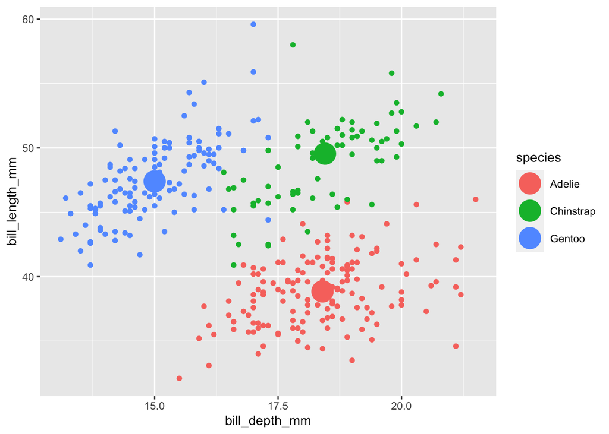

```r
penguins %>%
  ggplot()+
  aes(x = bill_depth_mm,
      y = bill_length_mm,
      color = species)+
  geom_point()+
  geom_point_xy_medians(size = 8)
```

### Optional: use ggplot2::layer_data to inspect the data ggplot2 prepared in the background

```r
layer_data(last_plot(),
           i = 2) # indicate which layer from the last plot
```

```
##    colour     x     y PANEL group shape size fill alpha stroke
## 1 #F8766D 18.40 38.85     1     1    19    8   NA    NA    0.5
## 2 #00BA38 18.45 49.55     1     2    19    8   NA    NA    0.5
## 3 #619CFF 15.00 47.40     1     3    19    8   NA    NA    0.5
```